# **Popular Historic Figures Exploration** by Julian Hernández

## Database Information

> Pantheon is a project developed by the Macro Connections group at The MIT Media Lab. It is a way to celebrate our acomplishments as a species by documentating our global heritage. You can find more about this dataset and project on [Kaggle](https://www.kaggle.com/mit/pantheon-project) or [Pantheon’s Official Site](http://pantheon.media.mit.edu/methods)

> This dataset gathers information on the 11,341 biographies that have presence in more than 25 languages in the Wikipedia (as of May 2013). This dataset is not restricted to any cultural domain or time period, including all biographies that are present in more than 25 different language editions of Wikipedia.

> The dataset has 17 variables from which I choose 12 to analyze.

```
## 'data.frame':    11337 obs. of  14 variables:
##  $ full_name                  : chr  "Aristotle" "Plato" "Jesus Christ" "Socrates" ...
##  $ birth_year                 : num  -384 -427 -4 -469 -356 ...
##  $ sex                        : Factor w/ 2 levels "Female","Male": 2 2 2 2 2 2 2 2 2 2 ...
##  $ country                    : Factor w/ 196 levels "","Afghanistan",..: 63 63 80 63 63 81 37 81 180 63 ...
##  $ continent                  : Factor w/ 8 levels "","Africa","Asia",..: 4 4 3 4 4 4 3 4 4 4 ...
##  $ occupation                 : Factor w/ 88 levels "Actor","American Football Player",..: 60 60 75 60 54 45 60 67 88 60 ...
##  $ industry                   : Factor w/ 27 levels "Activism","Business",..: 24 24 25 24 20 14 24 11 15 24 ...
##  $ domain                     : Factor w/ 8 levels "Arts","Business & Law",..: 4 4 5 4 5 7 4 5 4 4 ...
##  $ article_languages          : int  152 142 214 137 138 174 192 128 141 114 ...
##  $ page_views                 : int  56355172 46812003 60299092 40307143 48358148 88931135 22363652 43088745 20839405 26168219 ...
##  $ average_views              : int  370758 329662 281771 294213 350421 511098 116477 336631 147797 229546 ...
##  $ historical_popularity_index: num  32 32 31.9 31.7 31.6 ...
##  $ antiquity                  : num  2397 2440 2017 2482 2369 ...
##  $ hpi                        : num  32 32 31.9 31.7 31.6 ...
```

## Variable Description

> **full_name**: Name of the historical figure  
> **birth_year**: Birth Year of the historical figure in the Gregorian Calendar  
> **sex**: Biological Sex of the historical figure (Male / Female)  
> **country**: Country or modern day equivalent where the historical figure was born.  
> **continent**: Continent where the historical figure was born.  
> **occupation**: Profession the historical figure had.  
> **industry**: Industry of the historical figure.  
> **Domain**: Domain of Knowledge where the historical figure excelled.  
> **article_languages**: Number of Languages the historical figure biography is present in Wikipedia.  
> **page_views**: Total number of pageviews in all languages.  
> **average_views**: Total Number of pageviews divided by number of languages the biography is in.  
> **HPI** or **historical_popularity_index**: A more complex way to measure the historical impact by using the number of languagues, page views, age of the character, and the variation in pageviews per language.

```r
summary(db)
```

```
##   full_name           birth_year        sex                 country
##  Length:11337       Min.   :-3500   Female:1495   United States :2169
##  Class :character   1st Qu.: 1791   Male  :9842   United Kingdom:1147
##  Mode  :character   Median : 1919                 France        : 866
##                     Mean   : 1658                 Italy         : 809
##                     3rd Qu.: 1961                 Germany       : 748
##                     Max.   : 2005                 Unknown       : 433
##                                                   (Other)       :5165
##          continent               occupation               industry
##  Europe       :6366   Politician      :2528   Government      :2703
##  North America:2439   Actor           :1193   Film And Theatre:1374
##  Asia         :1188   Soccer Player   :1064   Team Sports     :1230
##  Africa       : 419   Writer          : 953   Music           :1054
##  Unknown      : 406   Religious Figure: 517   Language        : 998
##  South America: 366   Singer          : 437   Natural Sciences: 736
##  (Other)      : 153   (Other)         :4645   (Other)         :3242
##                   domain     article_languages   page_views
##  Institutions        :3453   Min.   : 26.00    Min.   :     1965
##  Arts                :2866   1st Qu.: 29.00    1st Qu.:   628928
##  Sports              :1756   Median : 35.00    Median :  1603951
##  Science & Technology:1366   Mean   : 40.77    Mean   :  4202224
##  Humanities          :1328   3rd Qu.: 46.00    3rd Qu.:  4485693
##  Public Figure       : 358   Max.   :214.00    Max.   :145250649
##  (Other)             : 210
##  average_views     historical_popularity_index   antiquity
##  Min.   :     49   Min.   : 9.879              Min.   :   8.0
##  1st Qu.:  18442   1st Qu.:20.432              1st Qu.:  52.0
##  Median :  43871   Median :23.027              Median :  94.0
##  Mean   :  89439   Mean   :22.308              Mean   : 354.7
##  3rd Qu.: 107243   3rd Qu.:24.589              3rd Qu.: 222.0
##  Max.   :1515232   Max.   :31.994              Max.   :5513.0
##
##       hpi
##  Min.   : 9.879
##  1st Qu.:20.432
##  Median :23.027
##  Mean   :22.308
##  3rd Qu.:24.589
##  Max.   :31.994
##
```

# Preliminar Questions

> Is there any guiding principle for historical popularity, maybe location, profession or time period? Which professions are more historically memorable or significant? Is there any difference in the behavior of men and woman in the data? How does location influences historical popularity? Is there any difference in the occupations that are remembered per location?

# Univariate Plots Section

## Year of Birth

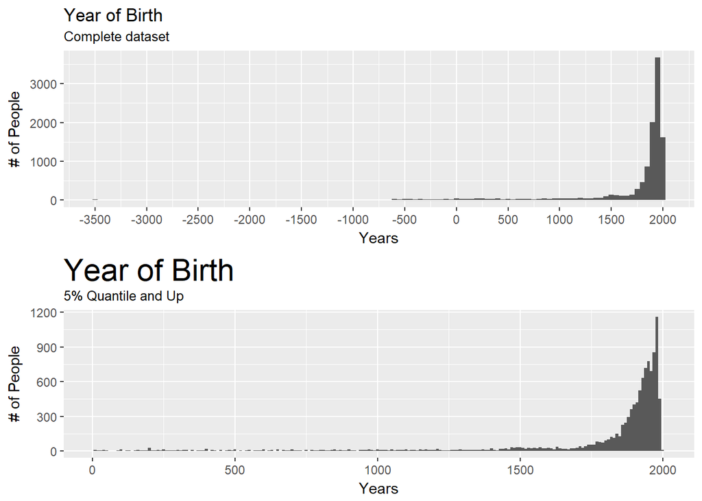

> **Year of Birth**: Most globally notable figures were born on recent times. Nevertheless there is huge variability, dates range from -3500 BC to 2005 AC.

> The data follows an upward trend towards recent times but it has a dip on the most recent years (1995 - 2010). Which could be due to the fact that people born on those years are fairly young and still need more time to develop their careers and skills. It could be also due to the specialization of skills needed to work on contemporary times, which makes teams more necessary and teams do not appear on the dataset.

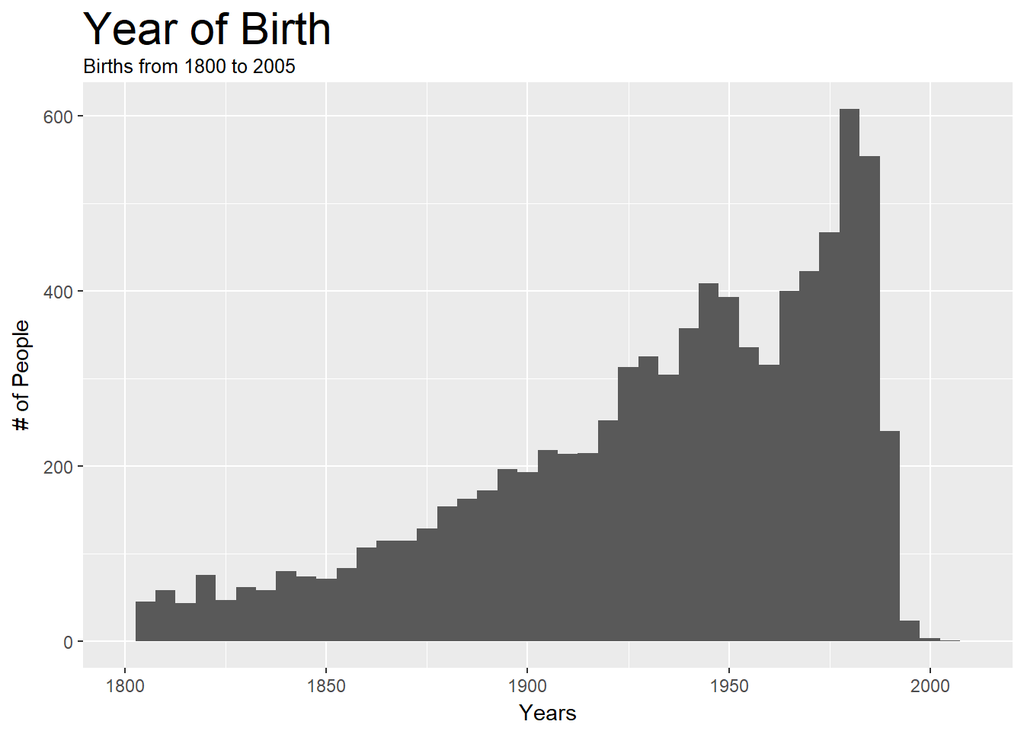

## Sex:

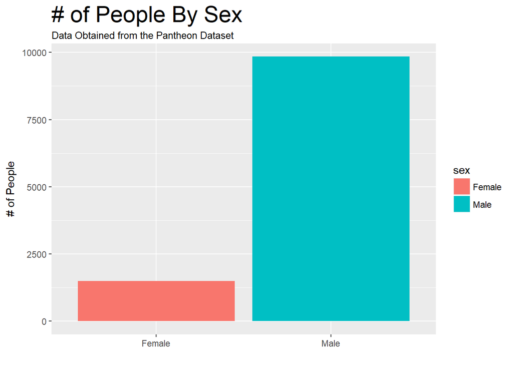

> There is a huge difference in the amount of men and women in the dataset. In this exploration it wont be possible to explain this imbalance, due to the fact that we are not looking at the complete dataset of biographies in wikipedia but a subset, the ones translated to more than 25 languages.

## Location

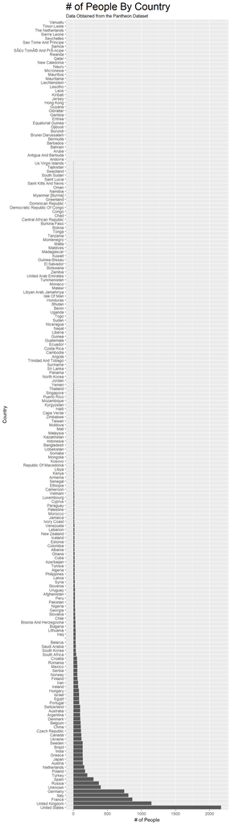

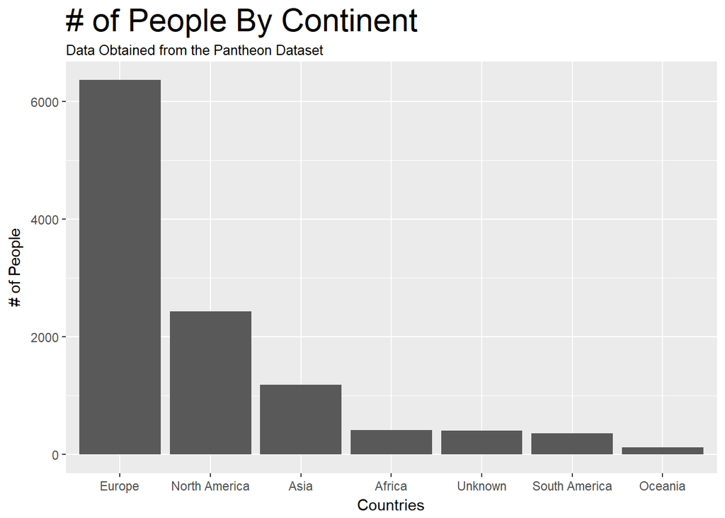

> In the past graphs we can see the distribution of great people among continents and countries.

> In terms of continents, most notable people come from Europe, followed by North America and then Asia. In terms of countries, the United States is followed by several european countries ( France, Germany, the UK and Italy).

> This reflects Wikipedia bias, a bias the authors of the dataset identify as an issue. Wikipedia is more popular in Western countries where European history and figures are studied and remembered. Continents with history that spans millenia and that have huge populations such as Asia or Africa are lacking in representation.

## Industry & Domain

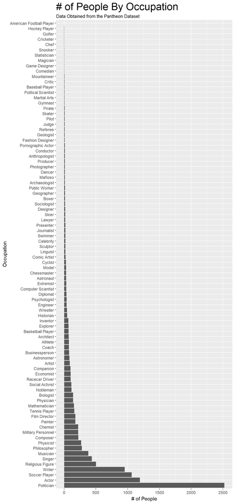

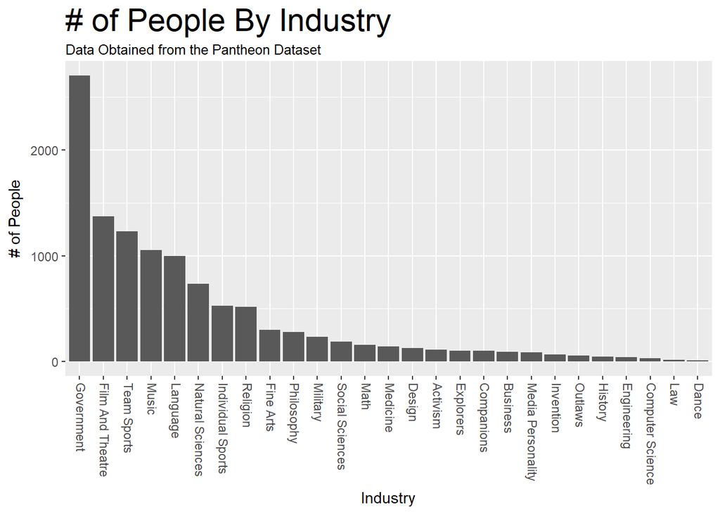

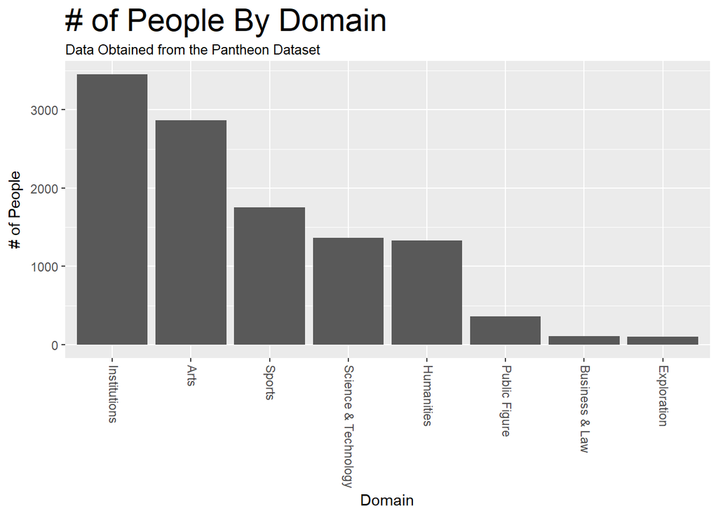

> Here we have the profession of the notable people on the dataset in decreasing levels of granularity. We can see their field divided by: occupation, industry and domain.

> The most common occupation in the dataset is that of politician, followed by several profession in the entertainment industry, football player, actor and writer. This translates to the distribution of great people by industry and domain, where most of them are located in goverment, the Arts and sports.

## Number of Languages

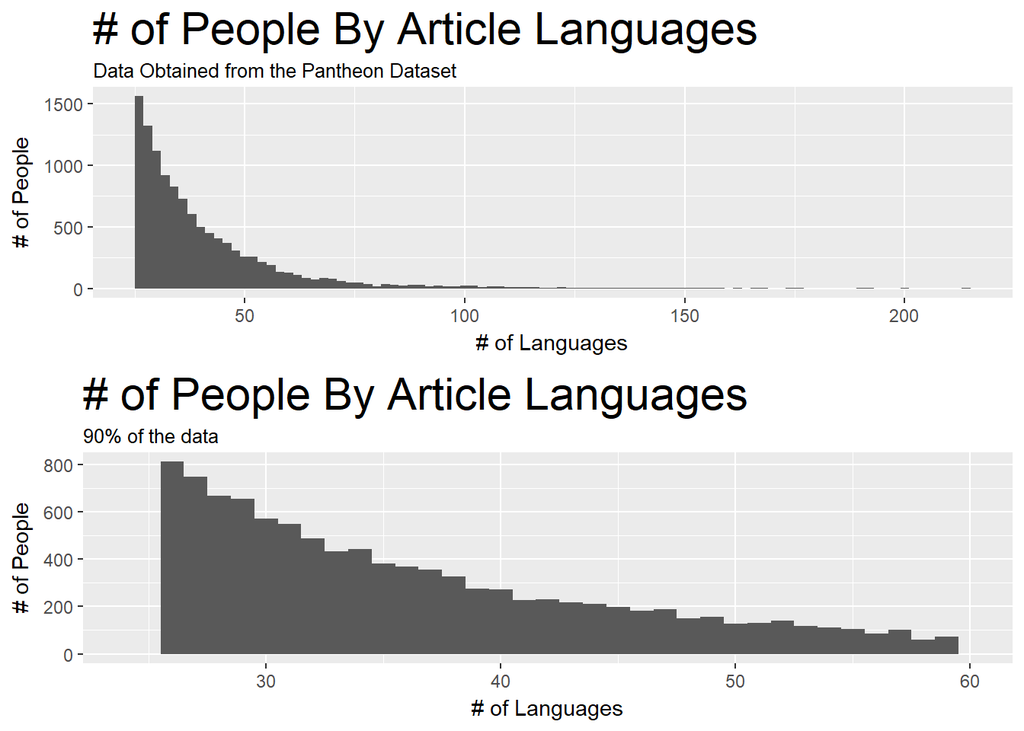

```
##    Min. 1st Qu.  Median    Mean 3rd Qu.    Max.
##   26.00   29.00   35.00   40.77   46.00  214.00
```

## Total Views & Average Views

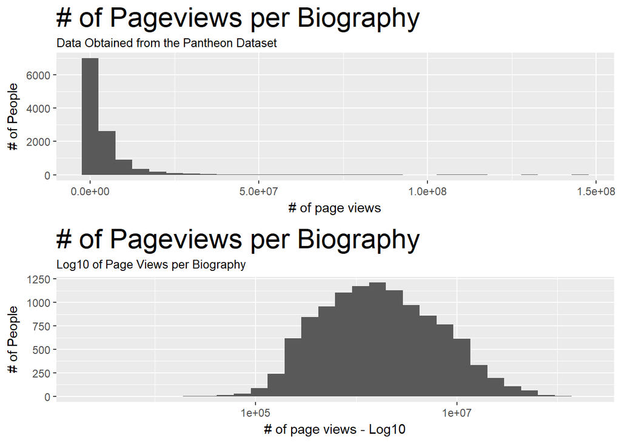

```r
summary(db$page_views)
```

```
##      Min.   1st Qu.    Median      Mean   3rd Qu.      Max.
##      1965    628928   1603951   4202224   4485693 145250649
```

> Nevertheless page views is filled with outliers, which are people that have changed the course of history or impacted their fields with a breath of fresh ideas. The poeple with most views on Wikipedia, on this dataset are: Michael Jackson, Adolf Hitler and Justin Bieber. An unlikely trio.

## Average Views

> Average Views is obtained by dividing the total number of page views by the amount of languages the article is available.

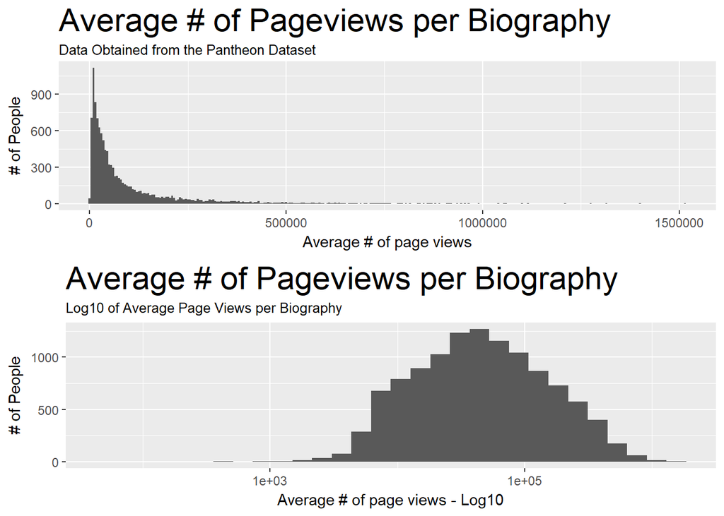

> Average Page Views behaves similar to total page views, is skewed to the right and when log10 is applied it normalizes its distribution. Nevertheless it doesnt’t measure the same as total page views. What average page views tell us is who is consistently more popular across several languages, but it is a mean measurement which still means that it is susceptible to large values inflating it. Perhaps a median would have been more useful to know the distribution of the page views.

> The biographies with the highest Average Page Views count are Kim Kardashian, Lil Wayne and Eminem.

## Historical Popularity Index (HPI)

> The HPI is calculated taking into account several key indicators. Such as the time passed since the historical figure lived, number of times their biography has been visited,the number of views in different languages and other key factors.

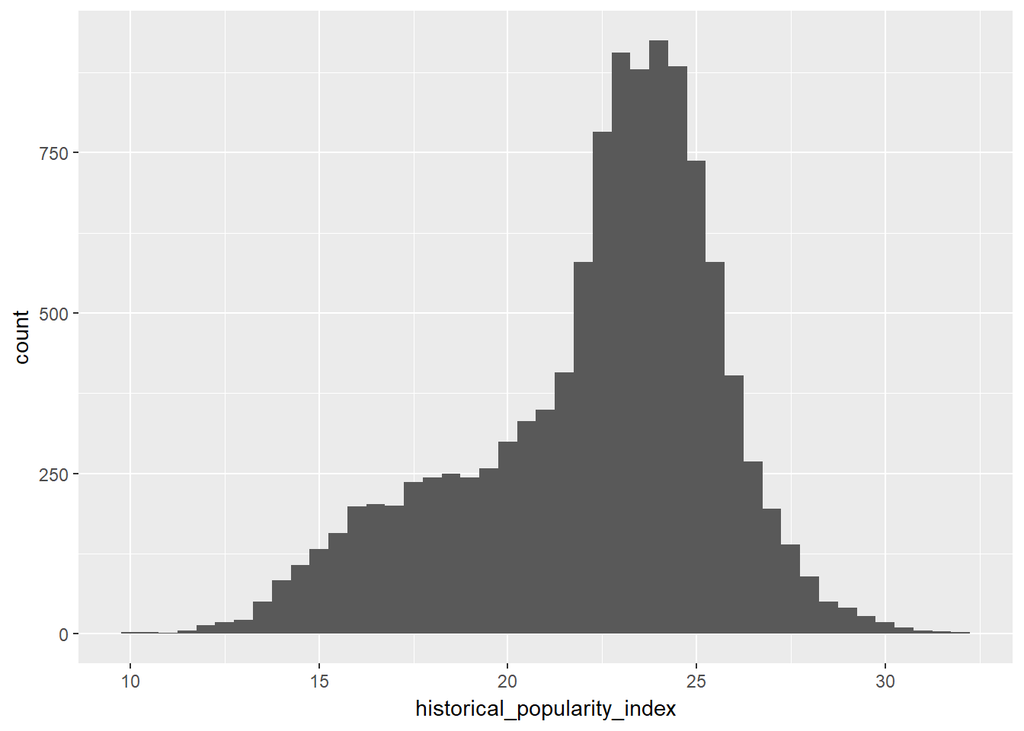

```r
summary(db$historical_popularity_index)
```

```
##    Min. 1st Qu.  Median    Mean 3rd Qu.    Max.
##   9.879  20.432  23.027  22.308  24.589  31.994
```

# Univariate Analysis

### What is the structure of your dataset?

> There are 11337 notable people in the dataset with 12 features (full_name, birth_year, sex, country, continent, occupation, industry, domain, article_languages, page_views, average_views, historical_popularity_index). There are several factors: continent, sex, industry and domain. But none of them are ordered.

### What is/are the main feature(s) of interest in your dataset?

> The features in the data set I’d like to explore are gender and the historical_popularity_index. I’d like to determine the relationship between these variables with the rest the dataset. I’d also like to know if there are variables that predict “historical relevance” and how good of a predictors are they.

### What other features in the dataset do you think will help support your investigation into your feature(s) of interest?

> I think domain, birth year, continent and the amount of languages the biography is translated to; might give an insight to the kind of historical figure that becomes popular on Wikipedia.

### Did you create any new variables from existing variables in the dataset?

> No, I only used existing variables.

### Of the features you investigated, were there any unusual distributions? Did you perform any operations on the data to tidy, adjust, or change the form of the data? If so, why did you do this?

> Most of the numeric variables are skewed to either the right or the left, most of them have lots of extreme values. In some of the variables, like page_views and average_views, I used log10 to transform the data so its distribution could be more easily seen and it could be more easily managed.

> I also transformed birth_years from a factor variable to a numeric variable. It was what made the most sense in order to visualize and analyze it.

> I also dropped variables such as longitude, latitude. The information they gave is pretty specific and is not something that a variable like continent or country wouldn’t tell me. I also dropped the state variable due to it’s specificity, it only applied to the US.

# Bivariate Plots Section

> There are two variables in the data I want to explore, Sex and HPI. During this exploration I will search for relationships between the other variables and those elements.

## Sex:

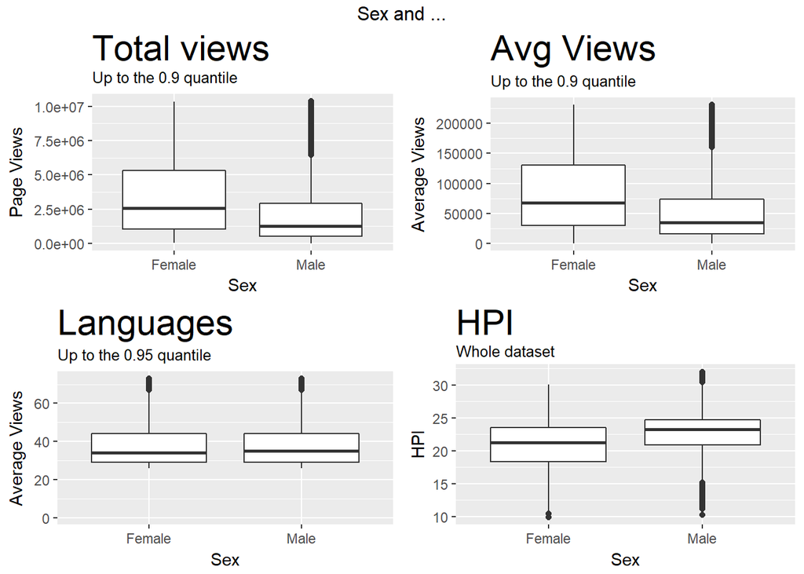

> Females tend to have more views than males on both, total views and average. But, men tend to have more outliers on the upper part of the boxplot. The only boxplot with a different behavior is the one for historical popularity, here men tend to have higher values than women, but men tend to have more outliers, just that in this case most of the outliers are on the lower part of the boxplot.

> Both Male and Females have similar distributions of languages in their biographies.

### Birth year

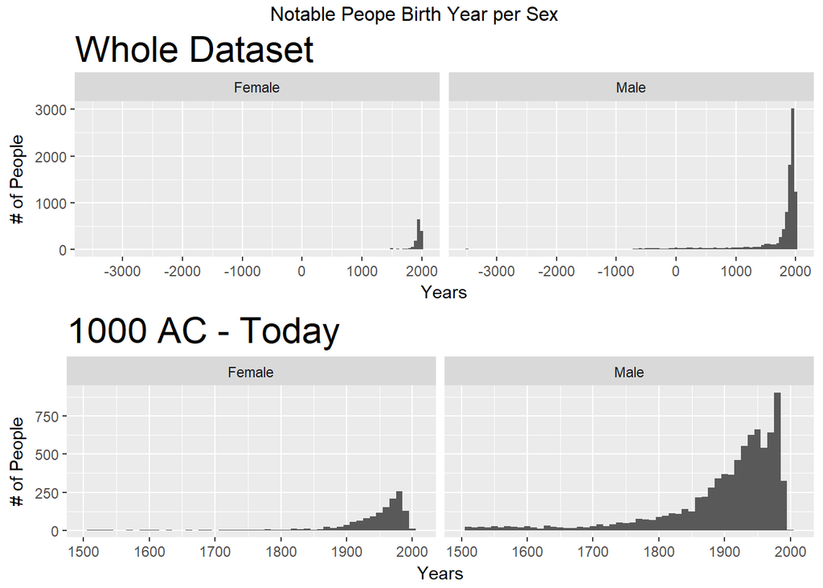

> We see the same explosion after 1750 in both sexes, but women lag behind for 250 years before seeing a truly significant growth. More women are known in recent times (1750 & up) than in the rest of human history. Nevertheless men have way more records than women, as we had seen in our previous analysis.

> We also see the same behavior that we observed before on both genders. Both of them rise until recent times where they have a small dip.

### Location

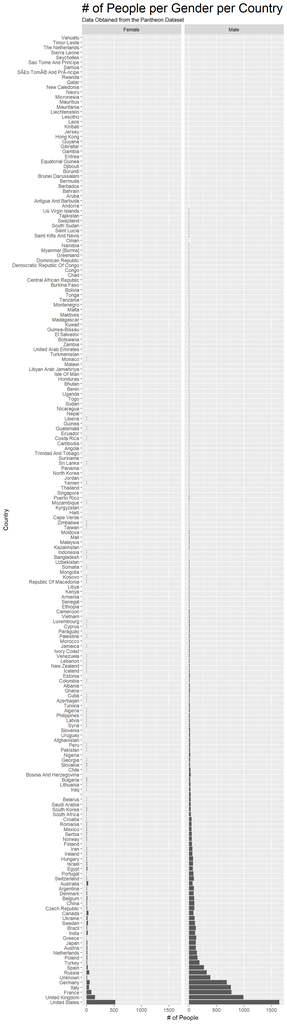

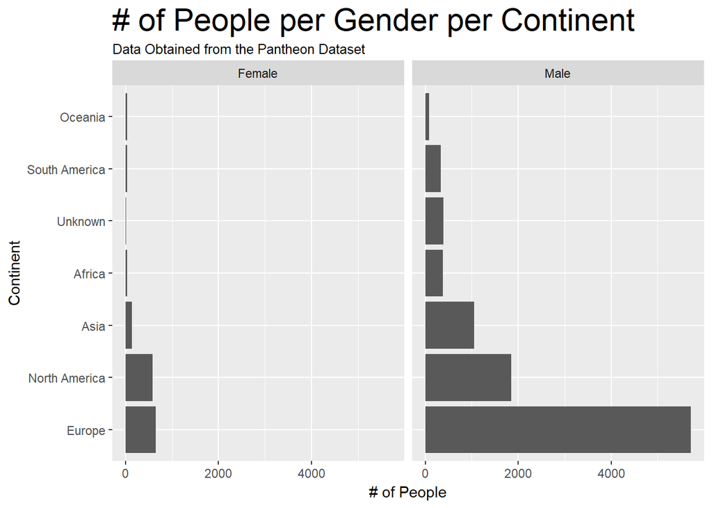

> Female historical figures were born mostly in the United States and follow a similar distribution to the general view we explored before. In other words, most of them where born in european countries or the US. One relevant difference between the two sexes is that most of the figures with **Unknown** nationality are men, not women.

> On the continent scale, Europe is barely holding to the first post in terms of women notable figures, North America is quickly catching up to them.

> The rest of the world, Africa, South America and OCeania, have almost no women notable figures.

### Profession

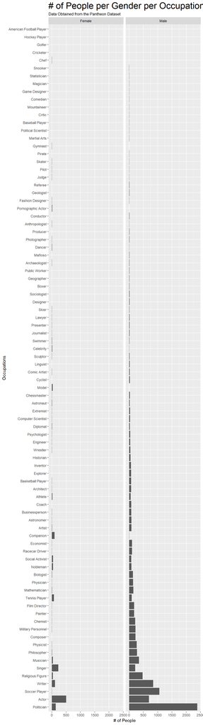

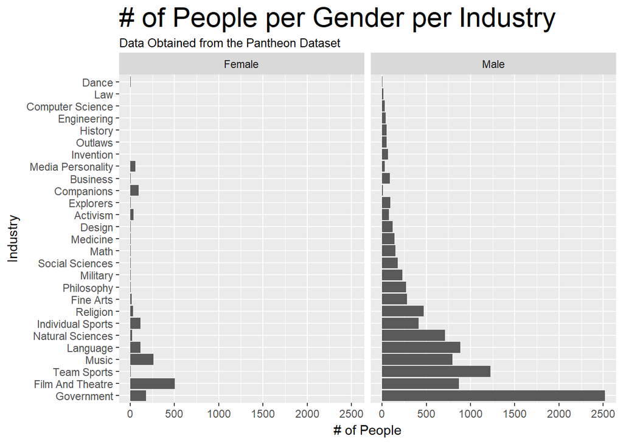

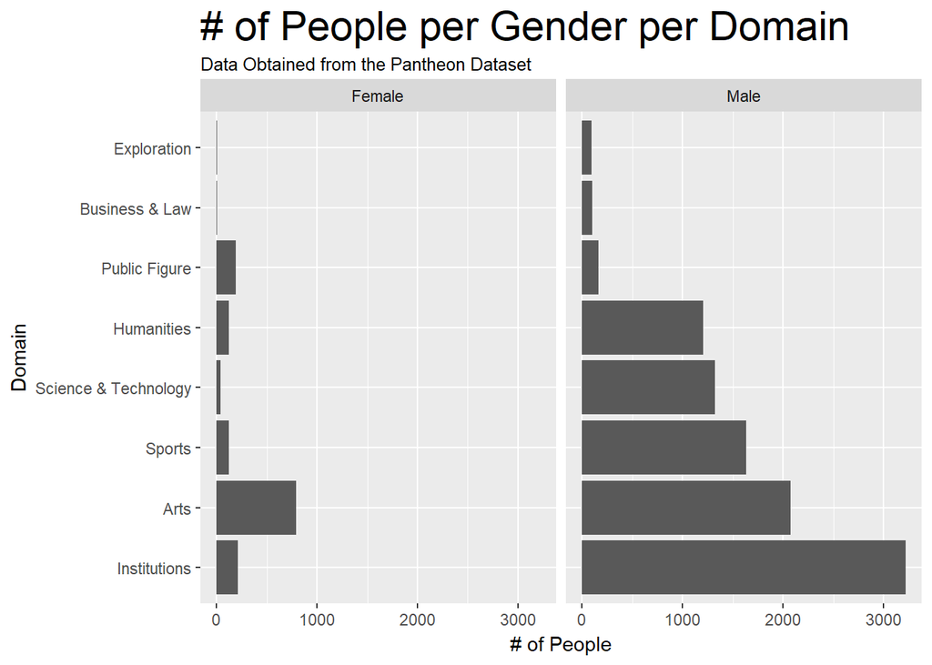

> At first glance we can see that among the less populated occupations in the dataset the division between genders gave us a clear divide. Some of the occupations in where this divide is evident are: gymnast, pornographic actor, model or companion tend to be roles fulfilled by women, there are few notable men on these roles. Meanwhile men dominate in roles such as historian, inventor, explorer or composer. Popular occupation with few notable women.

> Most notable women work in the Arts, specifically as actresess. Which we can see reflected on the distribution on the industry and domain fields.

> Here we see a big departure from the distribution we saw on the Domain univariate analysis. The distribution of domains for women are remarkably different than the one from men or the general one.

# Bivariate Analysis: Gender Exploration

> First of all, there were some differences in occupations between men and women. Most notable men worked in institutions while women worked in the Arts, especifically as actresses. The most popular profession for men was politician.

> In terms of location, most notable women came from the Unites States. With several European countries at it’s tail. Looking at the data from a continent perspective we see that Europe is the place where most notable women are born, followed by the US, Asia and a lack of figures coming from the rest of the world. Men location distribution is similar to the general one.

> Also, A big difference comes in terms of popularity, women tend to have more pageviews,in total and in average, than men. But men tend to be have a higher HPI than women. Both have similar distribution of languages.

> Through this exploration we could see the most common country for notable women to come from and which field would a woman most commonly work in. Nevertheless that is only the beginning. I would like to know from if there are relationships between views, country and occupation. For example:  
> - Is a Male French artist more popular than an American one? How about a Female one?  
> - Which is the most common occupation for notable women per country? How about by continent? And for men?  
> - What kind of occupation receives the most page views on Wikipedia?

# HPI

## Page Views & HPI

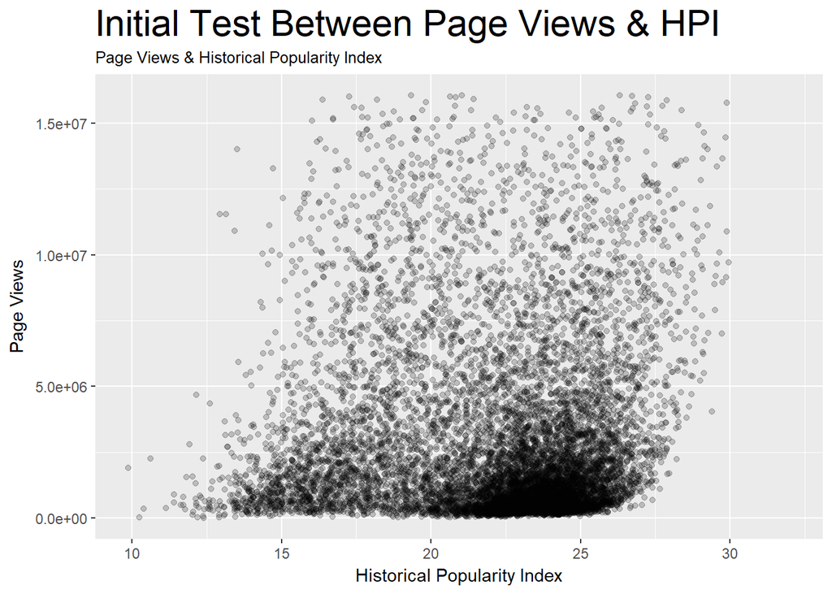

```
##
##  Pearson's product-moment correlation
##
## data:  db$hpi and db$page_views
## t = 10.046, df = 11335, p-value < 2.2e-16
## alternative hypothesis: true correlation is not equal to 0
## 95 percent confidence interval:
##  0.0756611 0.1121524
## sample estimates:
##       cor
## 0.0939383
```

> An initial analysis of the relationship between page views and HPI, seems to point to a lack of relationship between the two, The scatterplot and the pearson correlation index also guide us in that direction.

> In order to explore the relation of the page view variable with the HPI a bit more I decided to use log10 to normalize the distribution of page view.

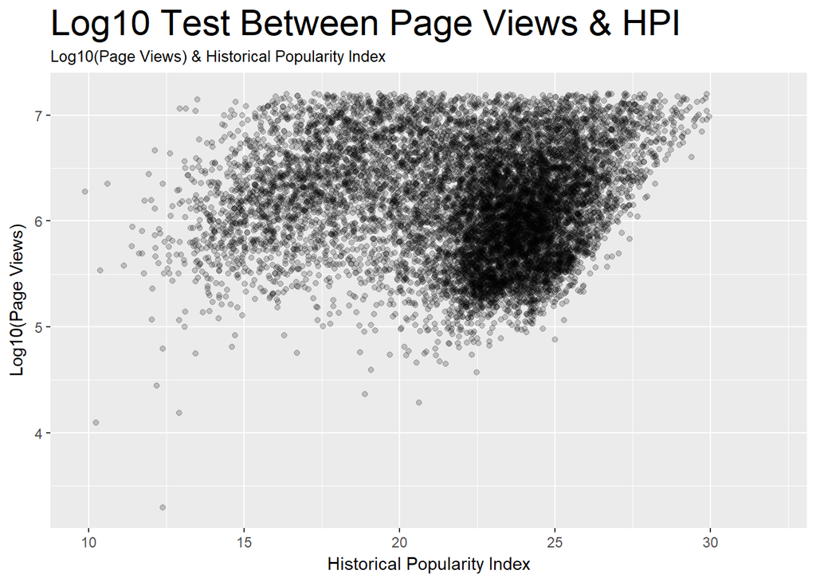

```
##
##  Pearson's product-moment correlation
##
## data:  db$hpi and log10(db$page_views)
## t = 5.9375, df = 11335, p-value = 2.978e-09
## alternative hypothesis: true correlation is not equal to 0
## 95 percent confidence interval:
##  0.03731294 0.07401490
## sample estimates:
##        cor
## 0.05568273
```

> After applying log10 to the variable we see that there is still no clear relationship between a HPI and page views.

> I double checked using the pearson correlation index, which is lower than it was before, almost 0, meaning “No relation”.

## Average Views

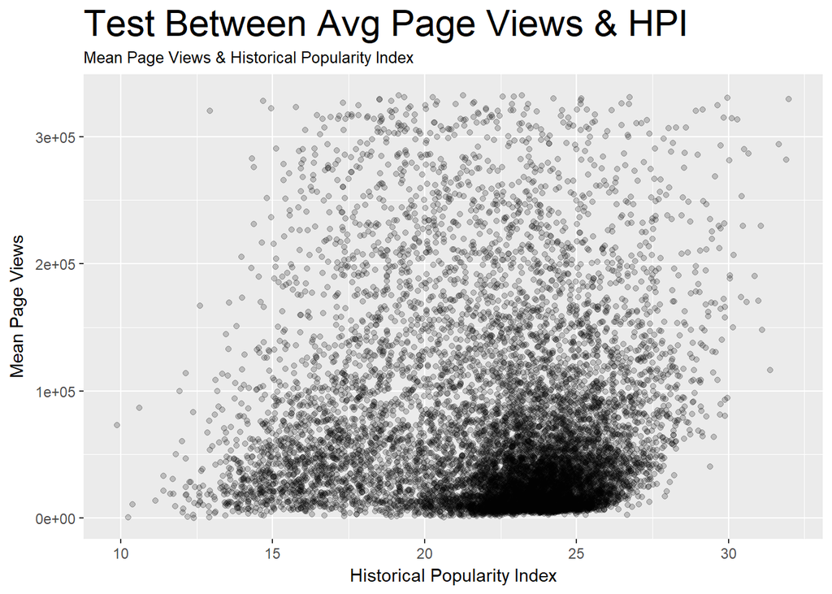

```
##
##  Pearson's product-moment correlation
##
## data:  db$hpi and db$average_views
## t = -9.5395, df = 11335, p-value < 2.2e-16
## alternative hypothesis: true correlation is not equal to 0
## 95 percent confidence interval:
##  -0.10747533 -0.07095238
## sample estimates:
##         cor
## -0.08924385
```

> I decided to run a similar process in average views as I ran in page_views. On the scatterplot we can se a lack of relationship between the variables. An hypothesis that is confirmed by the pearson correlation index, -0.08, which indicates a lack of relationship.

> I run the test again with log10, to see if normalizing the distribution of the variable helps.

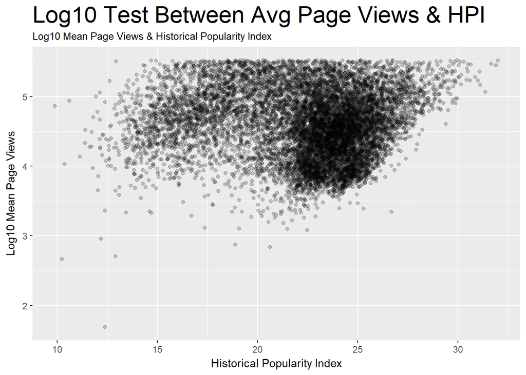

```
##
##  Pearson's product-moment correlation
##
## data:  db$hpi and log10(db$average_views)
## t = -7.1522, df = 11335, p-value = 9.069e-13
## alternative hypothesis: true correlation is not equal to 0
## 95 percent confidence interval:
##  -0.08532955 -0.04867882
## sample estimates:
##         cor
## -0.06702679
```

> Just as with page_views, using log10 makes the pearson coefficient go down.

> Both average and total page views seem to have little relevance in the importance of an historical figure.

## Birth Year

> In order to explore correlation between hpi and birth year I tranformed the birth year variable to avoid negative numbers using the following formula: **antiquity = 2013 - birth_year**.

> We substract from 2013 since the dataset was updated last on May 2013.

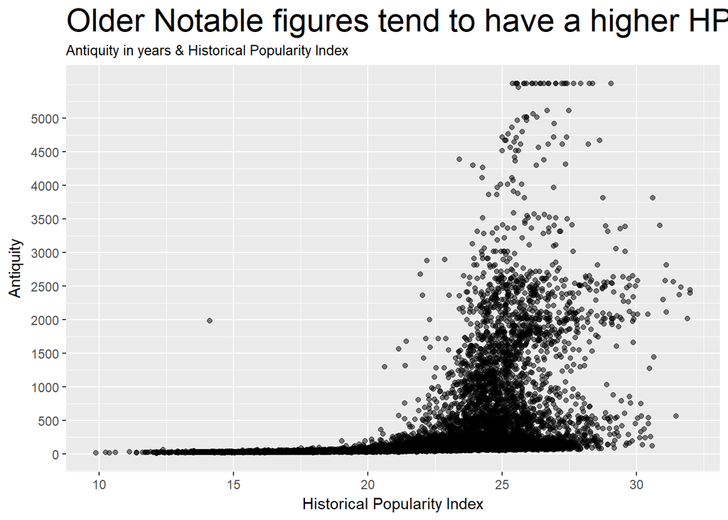

> Using the scatterplot we can see that recent great people then to have the most variance in HPI and older historical figures tend to have higher HPI. On the other side recent notable people are the only ones in the dataset with extremely low HPI values.

```
##
##  Pearson's product-moment correlation
##
## data:  db$hpi and log10(db$antiquity)
## t = 109.33, df = 11335, p-value < 2.2e-16
## alternative hypothesis: true correlation is not equal to 0
## 95 percent confidence interval:
##  0.7073565 0.7252787
## sample estimates:
##       cor
## 0.7164358
```

> Using the pearson correlation index we can see that antiquity and HPI are related. It could be one of the potential variables used to predict HPI.

## Average Languages

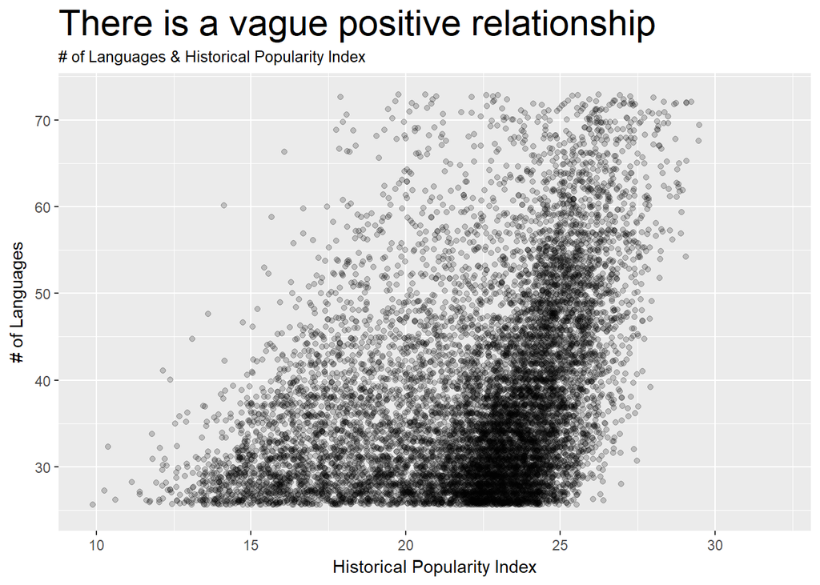

> There seems to be a vague positive relationship between HPI and # of Languages. The scatterplot is too disperse. I used pearson to check the relationship between the two.

```r
cor.test(db$hpi, db$article_languages)
```

```
##
##  Pearson's product-moment correlation
##
## data:  db$hpi and db$article_languages
## t = 52.566, df = 11335, p-value < 2.2e-16
## alternative hypothesis: true correlation is not equal to 0
## 95 percent confidence interval:
##  0.4277944 0.4573965
## sample estimates:
##       cor
## 0.4427161
```

> Languages and HPI have a high correlation index in comparison to page views or average views. Nevertheless 0.4 is still too low to consider a strong relationship between the two.

## Profession & Domain

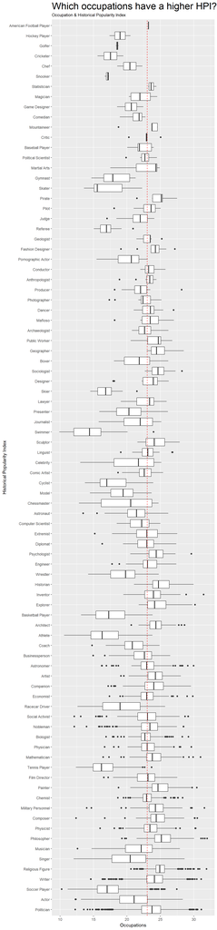

> In professions there are winners there losers. In the past graphic we can see are occupations that never rise above the median HPI, the worst case is the one of swimmers which fall behind every other profession. On the other side, The profession with the highest median HPI is philosophy.

> Other low performing occupations include: gymnast, skater, skier or tennis player.

> Other high performing occupations are: pirate, public worker or explorer.

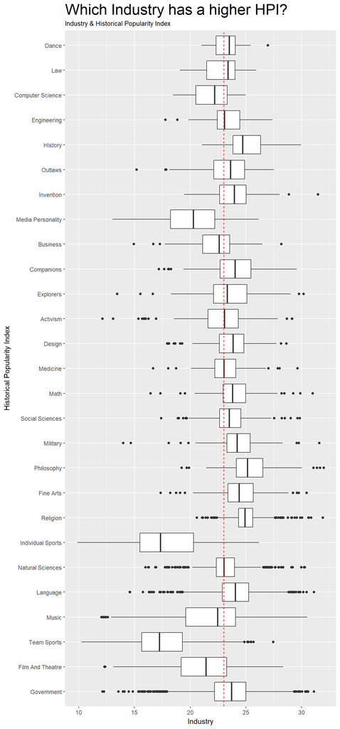

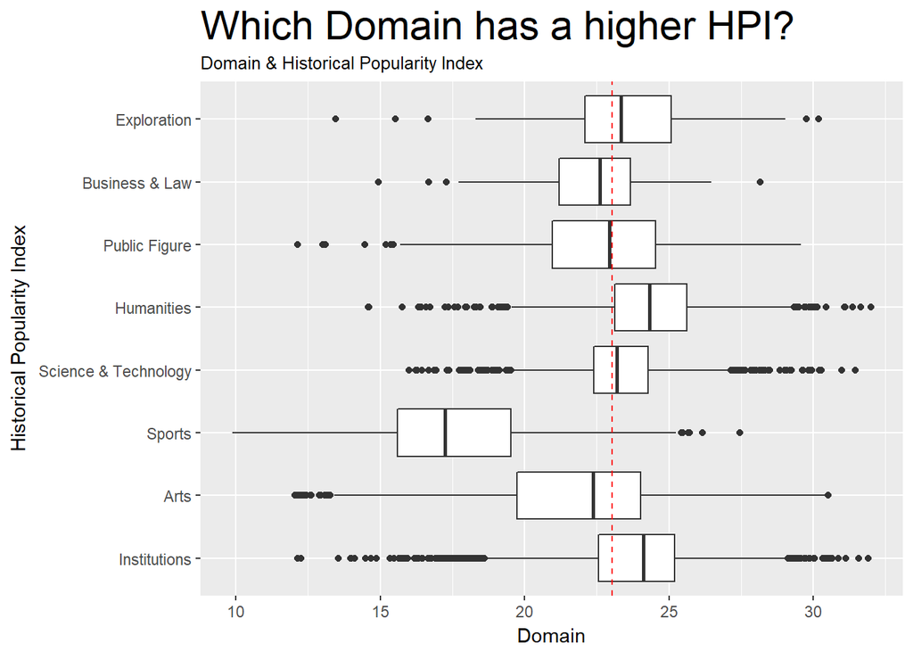

> In the past graphs we can see the picture painted in the occupation boxplots come to life.

> I have to point out that even though Fine Arts is doing great other fields of the arts are not that lucky: Music, Film & Theater and Media Personality are some of the worst performing industries.

> Finally it all comes together on domain, the Humanities (where philosophy is located) soar along with Institutions. While the Arts and Sports are the fields with the lowest HPI.

## Location

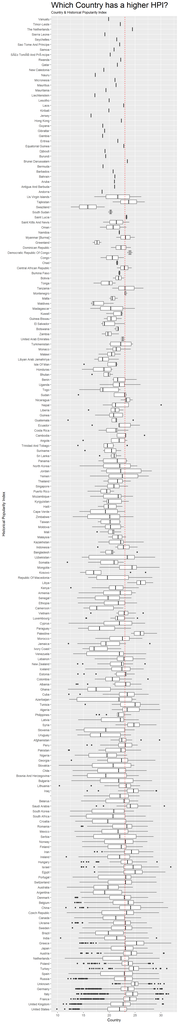

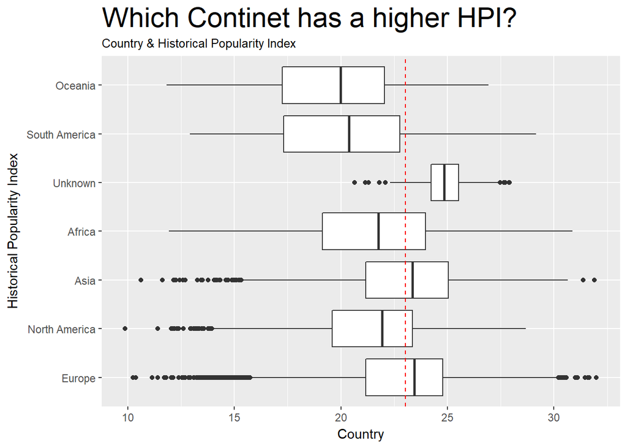

> Most countries fall under the median HPI line. With the country with the lowest HPI being Swaziland. The countriy with the highest HPI shouldn’t come as a surprise since their historical colaborations are well know. It is also known as the birthplace of Western Civilization, Greece.

> It also important to point out the behavior of the countries with the most notable people, the US, UK and France. The UK and the US have their respective medians below the global one and have lots of outliers in either side. Meanwhile, France behaves similarly to Germany and Italy. They have HPI higher than the global but also a lot of outliers pulling them down.

> Finally I have to point out that **Unknown** country has one of the highest HPIs.

> In terms of domain we see the past behavior reinforced. Most continents have low HPI levels only Europe, Asia and Unknown have median higher than the global median.

> I would also like to point out that North America has most of its values below the mean.

## Sex

> We analyzed the relationship between sex and HPI before. Men tend to have higher HPI values than women.

```r
by(db$hpi, db$sex, summary)
```

```
## db$sex: Female
##    Min. 1st Qu.  Median    Mean 3rd Qu.    Max.
##   9.879  18.328  21.238  20.889  23.512  30.037
## --------------------------------------------------------
## db$sex: Male
##    Min. 1st Qu.  Median    Mean 3rd Qu.    Max.
##   10.25   20.90   23.20   22.52   24.70   31.99
```

## General

```r
set.seed(4685)
db_subset <- subset(db, select =
                      c(antiquity, domain, continent,article_languages,
                        sex, page_views, average_views, hpi))

names(db_subset)
```

```
## [1] "antiquity"         "domain"            "continent"
## [4] "article_languages" "sex"               "page_views"
## [7] "average_views"     "hpi"
```

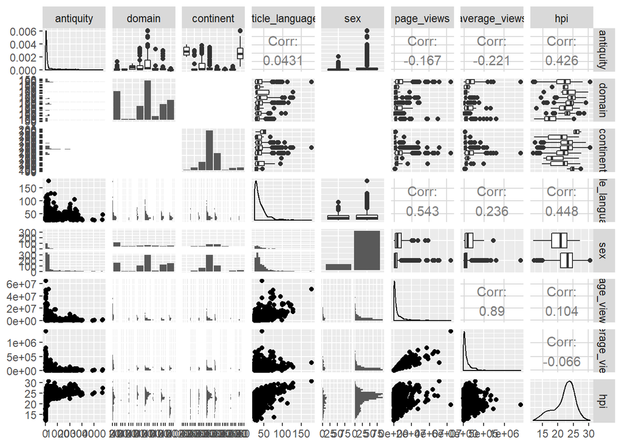

```r
ggpairs(db_subset[sample.int(nrow(db_subset), 1000),])
```

# Bivariate Analysis: HPI

> They main takeaway of the exploration of HPI was the lack of relationship between it and most variables. The exception being, Antiquity that has a strong correlation with HPI, and # of Languages.

> In terms of categorical variables of factors. In the next phase of the exploration I will only use the less granular format, domain for occupations and continent for countries.

> The Continent variable has a couple of surprises, Unknown is the highest median on the dataset followed by Europe or Asia. Surprisingly the US lacks behind. Continents like South America and Oceania have the lowest median overall.

> In this categorical variables we saw that the HPI distribution between factors is not equal, some have higher or lower HPIs. This proves helpful to our modelling ambitions.

## Did you observe any interesting relationships between the other features (not the main feature(s) of interest)?

# Multivariate Plots Section

# Multivariate Analysis

### Talk about some of the relationships you observed in this part of the investigation. Were there features that strengthened each other in terms of looking at your feature(s) of interest?

### Were there any interesting or surprising interactions between features?

### OPTIONAL: Did you create any models with your dataset? Discuss the strengths and limitations of your model.

# Final Plots and Summary

### Description Three

# Reflection